# Finding a line

Jarad Niemi

2021-07-13

# Bivariate data

Suppose you have a collection of x-y points, e.g.

```r
set.seed(20210701)
n <- 9
d <- data.frame(x = round(runif(n, 0, 100))) %>%
  mutate(y = round(x + rnorm(n, 0, 2)))
d
```

```
##    x  y
## 1  4  5
## 2 81 79
## 3 74 73
## 4 10 13
## 5 23 21
## 6 25 23
## 7 79 81
## 8 75 76
## 9 51 51
```

These points are defined by $(x_i,y_i)$ for $i=1,\ldots,N=9$. For example, for observation 1, we have $(4, 5)$.

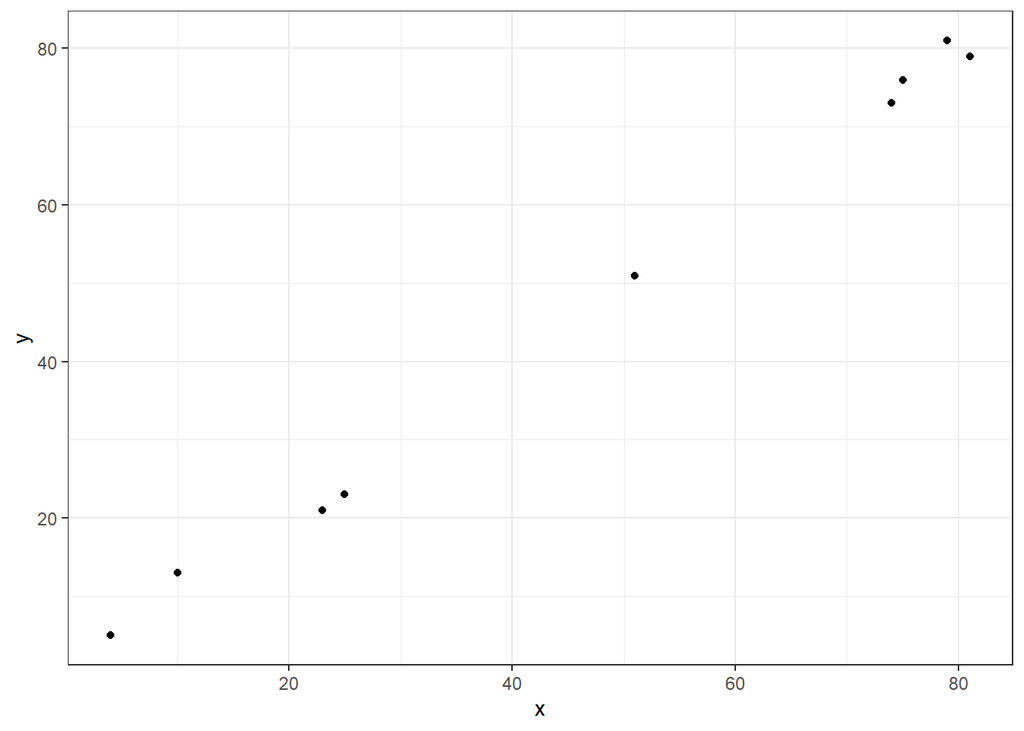

```r
ggplot(d, aes(x,y)) +
  geom_point()
```

## Residuals

For a proposed line $y=Mx+b$, the residual for observation $i$ is defined as
$$r_i = y_i - (Mx_i + b).$$

One approach to finding a line is to find the values for $M$ and $b$ that minimize the following function
$$f(M,b) = \sum_{i=1}^N |r_i| = \sum_{i=1}^N |y_i - (Mx_i + b)|.$$

An alternative approach is to find the values for $M$ and $b$ that minimize the following function
$$f(M,b) = \sum_{i=1}^N r_i^2 = \sum_{i=1}^N [y_i - (Mx_i + b)]^2$$

and we refer to this function as the sum of the squared residuals.

The values of $M$ and $b$ that minimize this sim of squared residuals is the regression line.

## Regression line

We can use calculus to take derivatives of this function with respect to $M$ and $b$ to find the values for $M$ and $b$ that minimize this sum. It turns out the formulas are

$$\hat{M} = \frac{SXY}{SXX} =
\frac{\sum_{i=1}^n (x_i-\overline{x})(y_i-\overline{y})}{\sum_{i=1}^n (x_i-\overline{x})^2}$$
and
$$\hat{b} = \overline{y} - \hat{M}\overline{x}$$
where
$$\overline{x} = \frac{1}{N} \sum_{i=1}^N x_i \quad \mbox{and} \quad
\overline{y} = \frac{1}{N} \sum_{i=1}^N y_i.$$

We use the carat over the slope and intercept to denote that these are estimates of the slope and intercept rather than the true values of the slope and the intercept. Since we have only a finite amount of data, we will never know the true slope and intercept.

Using the data above, we can find the slope and intercept using the following code

```r
attach(d) # puts x and y in the environment

xbar <- mean(x)
ybar <- mean(y)
sxx  <- sum( (x-mean(x))^2 )
sxy  <- sum( (x-mean(x))*(y-mean(x)) )

Mhat <- sxy/sxx
bhat <- ybar - Mhat*xbar
```

We can check out code using

```r
lm(y~x)
```

```
##
## Call:
## lm(formula = y ~ x)
##
## Coefficients:
## (Intercept)            x
##      0.3816       0.9919
```

## Using an optimizer to find the slope and intercept

Although we can derive the slope and intercept for this model, that will not always be possible. An alternative is to use a built-in optimizer. To use the optimizer we first need to build the function that we are trying to minimize.

```r
f <- function(parameters, y, x) {
  M <- parameters[1]
  b <- parameters[2]

  sum( (y - (M*x + b) )^2 )
}
```

Now we need to minimize f to find M and b

```r
o = optim(c(0,1), f, y = y, x = x)
```

First check convergence

```r
o$convergence
```

```
## [1] 0
```

This should be 0 for successful convergence. Anything else means something went wrong.

The optimized values are

```r
o$par
```

```
## [1] 0.9919635 0.3760112
```

## Exponential relationships

Suppose instead of a linear relationship between x and y, we have an exponential relationship, e.g.

$$y = c e^{Mx}.$$

Exponential relationships look like this

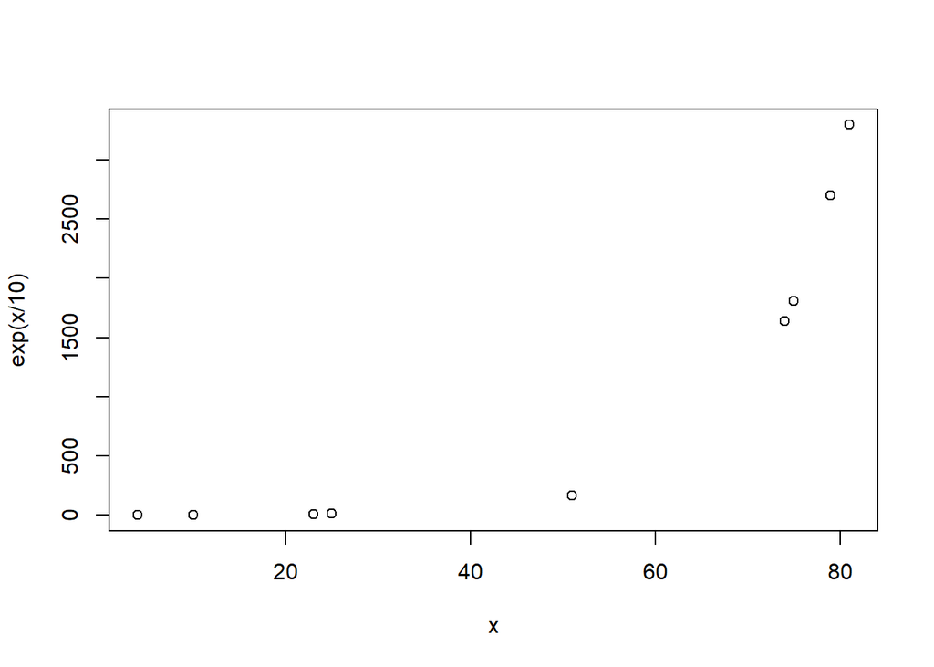

```r
plot(x, exp(x/10))
```

If we take a log of both sides, we have

$$\log(y) = \log(c) + Mx.$$

where $\log$ is the natural logarithm.

So the relationship is linear between $\log(y)$ and $x$ with slope $M$ and intercept $b = log(c)$. In this situation, we can find $c$ and $M$ by taking a log of the response variable $y$ and then calculating $c = e^\hat{b}$.

## Asymptotic relationships

Another possibility is that we have a relationship where y increases with x but the increase has diminishing returns and eventually y hits an asymptote (upper limit). One possible relationship is

$$y = b + c(1-e^{-d*x})$$

where $b$ is the intercept, $b+c$ is the asymptote, and $d$ controls how quickly that asymptote is reached.

An example of this relationship is

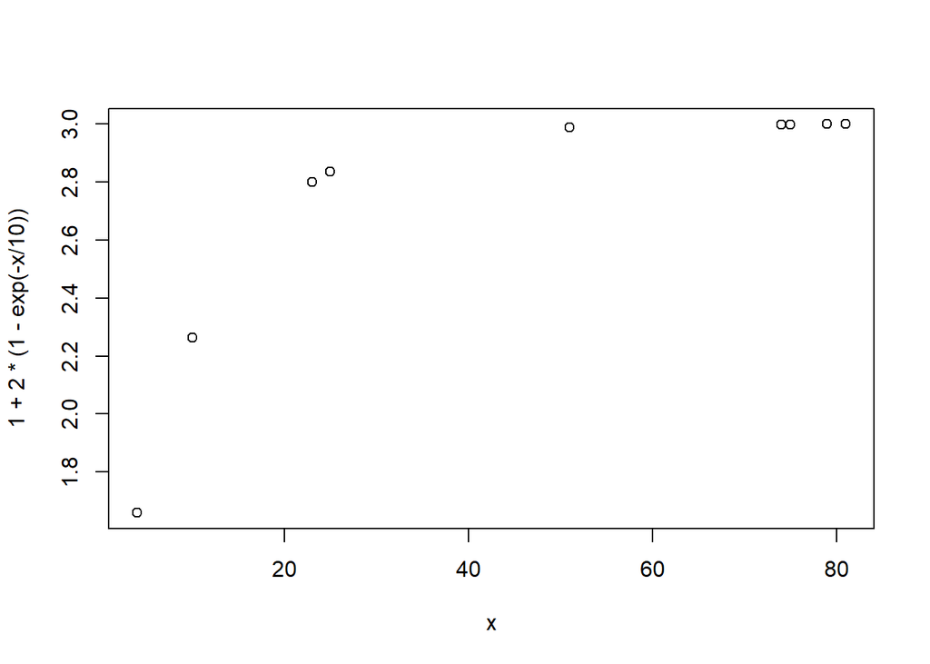

```r
plot(x, 1+2*(1-exp(-x/10)))
```